# c16

Hong Che

February 28, 2019

https://bioboot.github.io/bimm143_W19/class-material/lecture16_BIMM143_F18.html link of project

```r
library(DESeq2)
metaFile <- "data/GSE37704_metadata.csv"
countFile <- "data/GSE37704_featurecounts.csv"
```

Read the metadata file first with first row omitted

```r
colData = read.csv(metaFile, row.names = 1)
head(colData)
```

```
##               condition
## SRR493366 control_sirna
## SRR493367 control_sirna
## SRR493368 control_sirna
## SRR493369      hoxa1_kd
## SRR493370      hoxa1_kd
## SRR493371      hoxa1_kd
```

```r
countData = read.csv(countFile, row.names = 1)
head(countData)
```

```
##                 length SRR493366 SRR493367 SRR493368 SRR493369 SRR493370
## ENSG00000186092    918         0         0         0         0         0
## ENSG00000279928    718         0         0         0         0         0
## ENSG00000279457   1982        23        28        29        29        28
## ENSG00000278566    939         0         0         0         0         0
## ENSG00000273547    939         0         0         0         0         0
## ENSG00000187634   3214       124       123       205       207       212
##                 SRR493371
## ENSG00000186092         0
## ENSG00000279928         0
## ENSG00000279457        46
## ENSG00000278566         0
## ENSG00000273547         0
## ENSG00000187634       258
```

remove length col, and we need the right order need rows match exactly columns rid of first colhmn

```r
countData <- as.matrix(countData[,-1]) # only once
head(countData)
```

```
##                 SRR493366 SRR493367 SRR493368 SRR493369 SRR493370
## ENSG00000186092         0         0         0         0         0
## ENSG00000279928         0         0         0         0         0
## ENSG00000279457        23        28        29        29        28
## ENSG00000278566         0         0         0         0         0
## ENSG00000273547         0         0         0         0         0
## ENSG00000187634       124       123       205       207       212
##                 SRR493371
## ENSG00000186092         0
## ENSG00000279928         0
## ENSG00000279457        46
## ENSG00000278566         0
## ENSG00000273547         0
## ENSG00000187634       258
```

```r
dim(countData)
```

```
## [1] 19808     6
```

# why is there 0s

```r
rownames(colData)
```

```
## [1] "SRR493366" "SRR493367" "SRR493368" "SRR493369" "SRR493370" "SRR493371"
```

```r
colnames(countData)
```

```
## [1] "SRR493366" "SRR493367" "SRR493368" "SRR493369" "SRR493370" "SRR493371"
```

```r
all ( rownames(colData) == colnames( countData)) #return vector compare all
```

```
## [1] TRUE
```

Q. Complete the code below to filter countData to exclude genes (i.e. rows) where we have 0 read count across all samples (i.e. columns).remove first column Nice now lets setup the DESeqDataSet object required for the DESeq() function and then run the DESeq pipeline. This is again similar to our last days hands-on session.

```r
head(countData)
```

```
##                 SRR493366 SRR493367 SRR493368 SRR493369 SRR493370
## ENSG00000186092         0         0         0         0         0
## ENSG00000279928         0         0         0         0         0
## ENSG00000279457        23        28        29        29        28
## ENSG00000278566         0         0         0         0         0
## ENSG00000273547         0         0         0         0         0
## ENSG00000187634       124       123       205       207       212
##                 SRR493371
## ENSG00000186092         0
## ENSG00000279928         0
## ENSG00000279457        46
## ENSG00000278566         0
## ENSG00000273547         0
## ENSG00000187634       258
```

```r
# countData = countData[__, ]
countData = countData[rowSums(countData)!=0,]
head(countData)
```

```
##                 SRR493366 SRR493367 SRR493368 SRR493369 SRR493370
## ENSG00000279457        23        28        29        29        28
## ENSG00000187634       124       123       205       207       212
## ENSG00000188976      1637      1831      2383      1226      1326
## ENSG00000187961       120       153       180       236       255
## ENSG00000187583        24        48        65        44        48
## ENSG00000187642         4         9        16        14        16
##                 SRR493371
## ENSG00000279457        46
## ENSG00000187634       258
## ENSG00000188976      1504
## ENSG00000187961       357
## ENSG00000187583        64
## ENSG00000187642        16
```

how many genes do we have left?

```r
nrow(countData)
```

```
## [1] 15975
```

15975 ##Running Deseq2 # go to condition

```r
dds = DESeqDataSetFromMatrix(countData = countData,
                             colData = colData,
                             design = ~condition)
dds = DESeq(dds)
```

now results of HoxA1 knockdown vees control siRNA

```r
res = results(dds, contrast=c("condition", "hoxa1_kd", "control_sirna"))
summary((res))
```

```
##
## out of 15975 with nonzero total read count
## adjusted p-value < 0.1
## LFC > 0 (up)       : 4349, 27%
## LFC < 0 (down)     : 4396, 28%
## outliers [1]       : 0, 0%
## low counts [2]     : 1237, 7.7%
## (mean count < 0)
## [1] see 'cooksCutoff' argument of ?results
## [2] see 'independentFiltering' argument of ?results
```

plot volcano

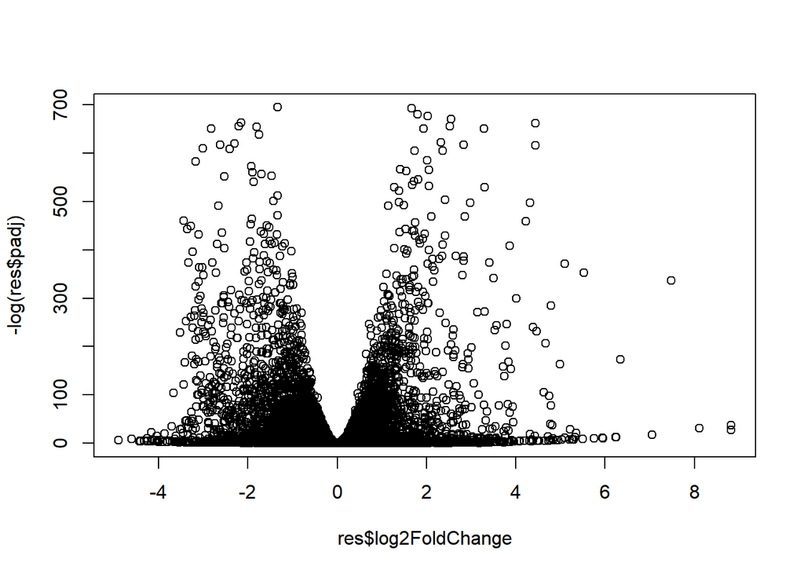

```r
plot( res$log2FoldChange, -log(res$padj))
```

```r
#smaller the better _
head(res)
```

```
## log2 fold change (MLE): condition hoxa1_kd vs control_sirna
## Wald test p-value: condition hoxa1 kd vs control sirna
## DataFrame with 6 rows and 6 columns
##                         baseMean     log2FoldChange              lfcSE
##                        <numeric>          <numeric>          <numeric>
## ENSG00000279457 29.9135794276176  0.179257083543324  0.324821566918811
## ENSG00000187634 183.229649921658  0.426457118513849  0.140265821358809
## ENSG00000188976 1651.18807619944 -0.692720464791275 0.0548465424860911
## ENSG00000187961 209.637938486147  0.729755610542653  0.131859900882201
## ENSG00000187583 47.2551232589398 0.0405765280481789  0.271892810160349
## ENSG00000187642 11.9797501642461  0.542810491962931  0.521559852177308
##                              stat               pvalue
##                         <numeric>            <numeric>
## ENSG00000279457 0.551863243699359     0.58104205296243
## ENSG00000187634  3.04034949057864  0.00236303765813393
## ENSG00000188976 -12.6301574063114 1.43989919007885e-36
## ENSG00000187961  5.53432548985905 3.12428316941044e-08
## ENSG00000187583  0.14923722339053    0.881366448843415
## ENSG00000187642  1.04074439337482    0.297994193826297
##                                 padj
##                            <numeric>
## ENSG00000279457    0.686554780450596
## ENSG00000187634  0.00515718184593185
## ENSG00000188976 1.76549369911665e-35
## ENSG00000187961 1.13413018105347e-07
## ENSG00000187583    0.919030615753096
## ENSG00000187642     0.40337931514274
```

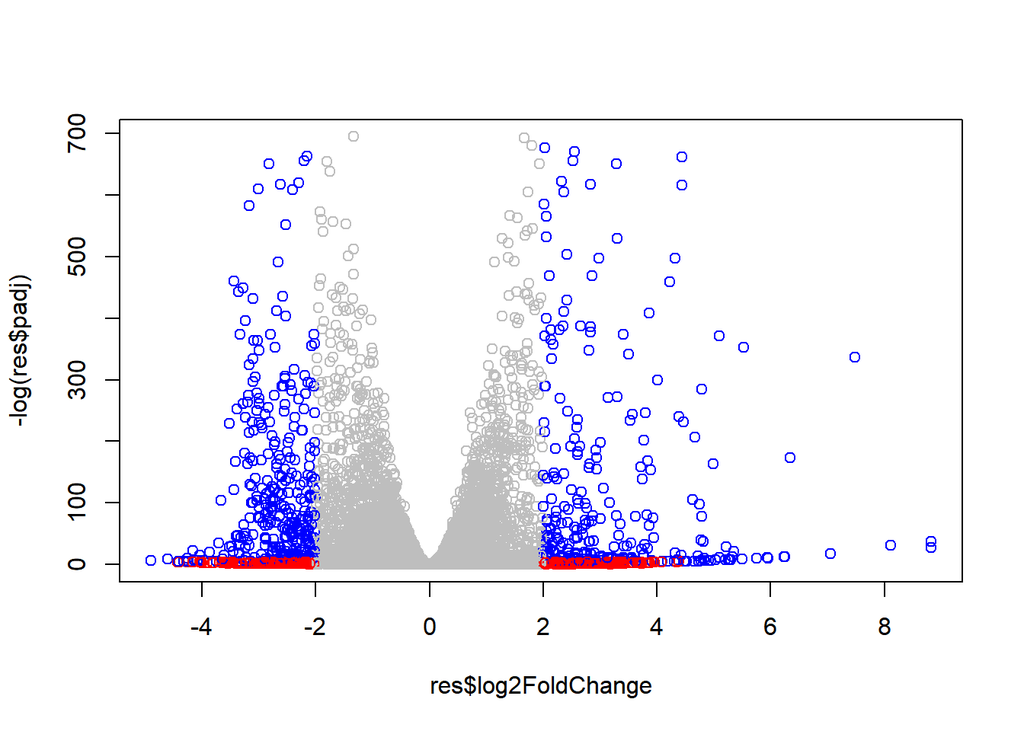

```r
mycols <- rep("gray", nrow(res)) #rep : replicate , 6 vector of rows
mycols[ abs(res$log2FoldChange) > 2] <- "red"

#use blue cols if fold change > 2 and P < .01
inds <- abs(res$log2FoldChange) >2 & res$padj <.01 # dont really need parenthesis
mycols[inds] <- "blue"
plot(res$log2FoldChange, -log(res$padj), col = mycols)
```

# Adding gene annotation

```r
source("http://bioconductor.org/biocLite.R")
biocLite("AnnotationDbi")
biocLite("org.Hs.eg.db")
```

```r
library("AnnotationDbi")
library("org.Hs.eg.db")
columns(org.Hs.eg.db)
```

```
##  [1] "ACCNUM"       "ALIAS"        "ENSEMBL"      "ENSEMBLPROT"
##  [5] "ENSEMBLTRANS" "ENTREZID"     "ENZYME"       "EVIDENCE"
##  [9] "EVIDENCEALL"  "GENENAME"     "GO"           "GOALL"
## [13] "IPI"          "MAP"          "OMIM"         "ONTOLOGY"
## [17] "ONTOLOGYALL"  "PATH"         "PFAM"         "PMID"
## [21] "PROSITE"      "REFSEQ"       "SYMBOL"       "UCSCKG"
## [25] "UNIGENE"      "UNIPROT"
```

```r
res$symbol = mapIds(org.Hs.eg.db,
                    keys=row.names(res),
                    keytype="ENSEMBL",
                    column="SYMBOL",
                    multiVals="first")
res$entrez = mapIds(org.Hs.eg.db,
                    keys=row.names(res),
                    keytype="ENSEMBL",
                    column="ENTREZID",
                    multiVals="first")
res$name =   mapIds(org.Hs.eg.db,
                    keys=row.names(res),
                    keytype="ENSEMBL",
                    column="GENENAME",
                    multiVals="first")
head(res, 10)# ck select()!
```

```
## log2 fold change (MLE): condition hoxa1_kd vs control_sirna
## Wald test p-value: condition hoxa1 kd vs control sirna
## DataFrame with 10 rows and 9 columns
##                          baseMean     log2FoldChange              lfcSE
##                         <numeric>          <numeric>          <numeric>
## ENSG00000279457  29.9135794276176  0.179257083543324  0.324821566918811
## ENSG00000187634  183.229649921658  0.426457118513849  0.140265821358809
## ENSG00000188976  1651.18807619944 -0.692720464791275 0.0548465424860911
## ENSG00000187961  209.637938486147  0.729755610542653  0.131859900882201
## ENSG00000187583  47.2551232589398 0.0405765280481789  0.271892810160349
## ENSG00000187642  11.9797501642461  0.542810491962931  0.521559852177308
## ENSG00000188290  108.922127976716   2.05706383469129  0.196905313983705
## ENSG00000187608   350.71686801731  0.257383686590174  0.102726560900025
## ENSG00000188157    9128.439421961  0.389908792023376 0.0467163405556556
## ENSG00000237330 0.158192358990472  0.785955208142751    4.0804728567969
##                              stat               pvalue
##                         <numeric>            <numeric>
## ENSG00000279457 0.551863243699359     0.58104205296243
## ENSG00000187634  3.04034949057864  0.00236303765813393
## ENSG00000188976 -12.6301574063114 1.43989919007885e-36
## ENSG00000187961  5.53432548985905 3.12428316941044e-08
## ENSG00000187583  0.14923722339053    0.881366448843415
## ENSG00000187642  1.04074439337482    0.297994193826297
## ENSG00000188290  10.4469696275516  1.5128195811837e-25
## ENSG00000187608   2.5055222752046   0.0122270696352063
## ENSG00000188157  8.34630425640589 7.04322218409625e-17
## ENSG00000237330 0.192613757210411    0.847261469988086
##                                 padj      symbol      entrez
##                            <numeric> <character> <character>
## ENSG00000279457    0.686554780450596          NA          NA
## ENSG00000187634  0.00515718184593185      SAMD11      148398
## ENSG00000188976 1.76549369911665e-35       NOC2L       26155
## ENSG00000187961 1.13413018105347e-07      KLHL17      339451
## ENSG00000187583    0.919030615753096     PLEKHN1       84069
## ENSG00000187642     0.40337931514274       PERM1       84808
## ENSG00000188290 1.30538261050851e-24        HES4       57801
## ENSG00000187608   0.0237452302389868       ISG15        9636
## ENSG00000188157 4.21963449387034e-16        AGRN      375790
## ENSG00000237330                   NA      RNF223      401934
##                                                                     name
##                                                              <character>
## ENSG00000279457                                                       NA
## ENSG00000187634                 sterile alpha motif domain containing 11
## ENSG00000188976 NOC2 like nucleolar associated transcriptional repressor
## ENSG00000187961                              kelch like family member 17
## ENSG00000187583                 pleckstrin homology domain containing N1
## ENSG00000187642             PPARGC1 and ESRR induced regulator, muscle 1
## ENSG00000188290                   hes family bHLH transcription factor 4
## ENSG00000187608                            ISG15 ubiquitin-like modifier
## ENSG00000188157                                                    agrin
## ENSG00000237330                                  ring finger protein 223
```

Q finally reorder these results

```r
res = res[order(res$pvalue),] #results taken by first and mapped to diff database and automated function finding in later sections
write.csv( res , file = "deseq_results.csv")
head(read.csv("deseq_results.csv")) # read results
```

```
##                 X baseMean log2FoldChange      lfcSE      stat pvalue padj
## 1 ENSG00000117519 4483.627      -2.422719 0.06000162 -40.37756      0    0
## 2 ENSG00000183508 2053.881       3.201955 0.07241720  44.21540      0    0
## 3 ENSG00000159176 5692.463      -2.313738 0.05755337 -40.20160      0    0
## 4 ENSG00000150938 7442.986      -2.059631 0.05384491 -38.25118      0    0
## 5 ENSG00000116016 4423.947      -1.888019 0.04316799 -43.73656      0    0
## 6 ENSG00000136068 3796.127      -1.649792 0.04393544 -37.55037      0    0
##   symbol entrez                                        name
## 1   CNN3   1266                                  calponin 3
## 2 FAM46C  54855 family with sequence similarity 46 member C
## 3  CSRP1   1465         cysteine and glycine rich protein 1
## 4  CRIM1  51232 cysteine rich transmembrane BMP regulator 1
## 5  EPAS1   2034            endothelial PAS domain protein 1
## 6   FLNB   2317                                   filamin B
```

# mapped genes to databases and now need see packages that automate finding genes functions

# now install packages for pathway viewing

```r
source("http://bioconductor.org/biocLite.R")
biocLite( c("pathview", "gage", "gageData") )
```

```r
library (pathview)
```

[output not shown]

```r
library (gage)
library(gageData)
data(kegg.sets.hs)
data(sigmet.idx.hs)

# Focus on signaling and metabolic pathways only
kegg.sets.hs = kegg.sets.hs[sigmet.idx.hs]

# Examine the first 3 pathways
head(kegg.sets.hs, 3)
```

```
## $`hsa00232 Caffeine metabolism`
## [1] "10"   "1544" "1548" "1549" "1553" "7498" "9"
##
## $`hsa00983 Drug metabolism - other enzymes`
##  [1] "10"     "1066"   "10720"  "10941"  "151531" "1548"   "1549"
##  [8] "1551"   "1553"   "1576"   "1577"   "1806"   "1807"   "1890"
## [15] "221223" "2990"   "3251"   "3614"   "3615"   "3704"   "51733"
## [22] "54490"  "54575"  "54576"  "54577"  "54578"  "54579"  "54600"
## [29] "54657"  "54658"  "54659"  "54963"  "574537" "64816"  "7083"
## [36] "7084"   "7172"   "7363"   "7364"   "7365"   "7366"   "7367"
## [43] "7371"   "7372"   "7378"   "7498"   "79799"  "83549"  "8824"
## [50] "8833"   "9"      "978"
##
## $`hsa00230 Purine metabolism`
##   [1] "100"    "10201"  "10606"  "10621"  "10622"  "10623"  "107"
```

[output cut: 23 more lines]

The main gage() function requires a named vector of fold changes, where the names of the values are the Entrez gene IDs.

Note that we used the mapIDs() function above to obtain Entrez gene IDs (stored in res$entrez) and we have the fold change results from DESeq2 analysis (stored in res$log2FoldChange).

```r
foldchanges = res$log2FoldChange
names(foldchanges) = res$entrez
head(foldchanges)
```

```
##      1266     54855      1465     51232      2034      2317
## -2.422719  3.201955 -2.313738 -2.059631 -1.888019 -1.649792
```

```r
#get results
keggres = gage(foldchanges, gsets=kegg.sets.hs)
attributes(keggres)
```

```
## $names
## [1] "greater" "less"    "stats"
```

```r
head(keggres$less)
```

```
##                                          p.geomean stat.mean        p.val
## hsa04110 Cell cycle                   8.995727e-06 -4.378644 8.995727e-06
## hsa03030 DNA replication              9.424076e-05 -3.951803 9.424076e-05
## hsa03013 RNA transport                1.375901e-03 -3.028500 1.375901e-03
## hsa03440 Homologous recombination     3.066756e-03 -2.852899 3.066756e-03
## hsa04114 Oocyte meiosis               3.784520e-03 -2.698128 3.784520e-03
## hsa00010 Glycolysis / Gluconeogenesis 8.961413e-03 -2.405398 8.961413e-03
##                                             q.val set.size         exp1
## hsa04110 Cell cycle                   0.001448312      121 8.995727e-06
## hsa03030 DNA replication              0.007586381       36 9.424076e-05
## hsa03013 RNA transport                0.073840037      144 1.375901e-03
## hsa03440 Homologous recombination     0.121861535       28 3.066756e-03
## hsa04114 Oocyte meiosis               0.121861535      102 3.784520e-03
## hsa00010 Glycolysis / Gluconeogenesis 0.212222694       53 8.961413e-03
```

```r
pathview (gene.data = foldchanges, pathway.id = "hsa04110")
```

```
## Info: Working in directory C:/Users/henry/workspace/Bimm181/143stuff/bim143_github/c16
```

```
## Info: Writing image file hsa04110.pathview.png
```

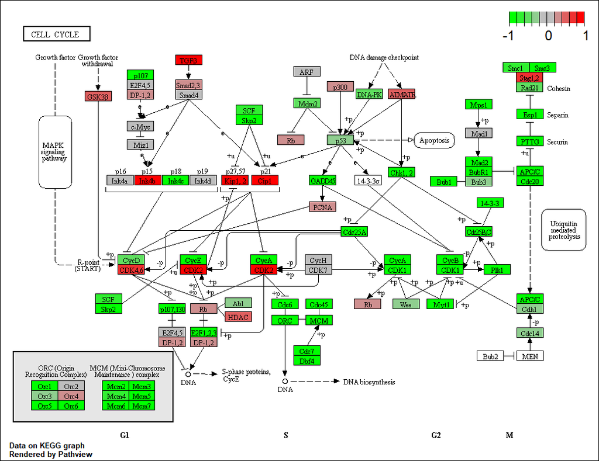

[figure not shown]

```r
# A different PDF based output of the same data
temp <- (pathview(gene.data=foldchanges, pathway.id="hsa04110", kegg.native=FALSE)) ## need to know how to print! this graph
```

```
## Info: Working in directory C:/Users/henry/workspace/Bimm181/143stuff/bim143_github/c16
```

```
## Info: Writing image file hsa04110.pathview.pdf
```

```r
temp
```

```
## $plot.data.gene
##    kegg.names  labels
## 1        1029  CDKN2A
## 2       51343    FZR1
## 3        4171    MCM2
## 4        4998    ORC1
## 5         996   CDC27
## 6         996   CDC27
## 7        6500    SKP1
## 8        6500    SKP1
## 9       23594    ORC6
## 10      23595    ORC3
## 11       5001    ORC5
## 12       5000    ORC4
## 13       4999    ORC2
```

[output cut: 268 more lines]